# Class notes 12.1

```r
library(tidyverse)
library(broom)
```

# Problem 1

Different Species have different Sepal width levels?

$H_0$: the population means of `Sepal.Width` are the same for all `Species`

$H_a$: the population means of `Sepal.width` are not the same for all `Species`

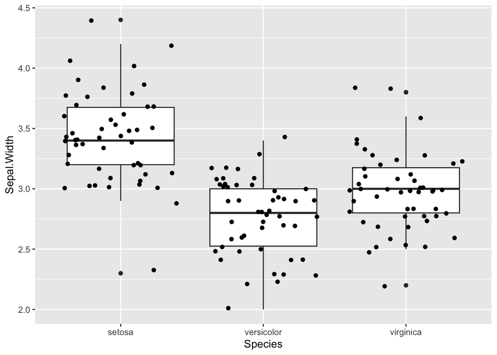

```r
iris <- iris %>%
  mutate(Species = as.factor(Species))

ggplot(iris, aes(x = Species,
                  y = Sepal.Width)) +
  geom_boxplot() +
  geom_jitter()
```

```r
model <- aov(iris$Sepal.Width ~ iris$Species)
summary(model)
```

```
              Df Sum Sq Mean Sq F value Pr(>F)
iris$Species   2  11.35   5.672   49.16 <2e-16 ***
Residuals    147  16.96   0.115
---
Signif. codes:  0 '***' 0.001 '**' 0.01 '*' 0.05 '.' 0.1 ' ' 1
```

The tiny p-value indicates good evidence against the null. We can conclude that `Species` does give information about `Sepal.Width`. Plants of different `Species` do seem to have different `Sepal.Width`

# Problem 2

```r
TukeyHSD(model)
```

```
  Tukey multiple comparisons of means
    95% family-wise confidence level

Fit: aov(formula = iris$Sepal.Width ~ iris$Species)

$`iris$Species`
                       diff         lwr        upr     p adj
versicolor-setosa    -0.658 -0.81885528 -0.4971447 0.0000000
virginica-setosa     -0.454 -0.61485528 -0.2931447 0.0000000
virginica-versicolor  0.204  0.04314472  0.3648553 0.0087802
```

There is sufficient evidence to show difference in Sepal.Width between the species versicolor - setosa There is sufficient evidence to show difference in Sepal.Width between the species virginica- setosa

because for both of these the p_adj = 0 < 0.05?

There is a slightly weak evidence to show difference in Sepal.Width between species virginica_versicolor since p_adj = 0.009 < 0.05

# Problem 3

Regression considers a possible *linear* relationship.

$H_0$: there is no linear relationship between the variables. The slop of the line of best fit is zero.

$H_a$: there is a linear relationship between the variable. The slope of the line of best fit is non-zero

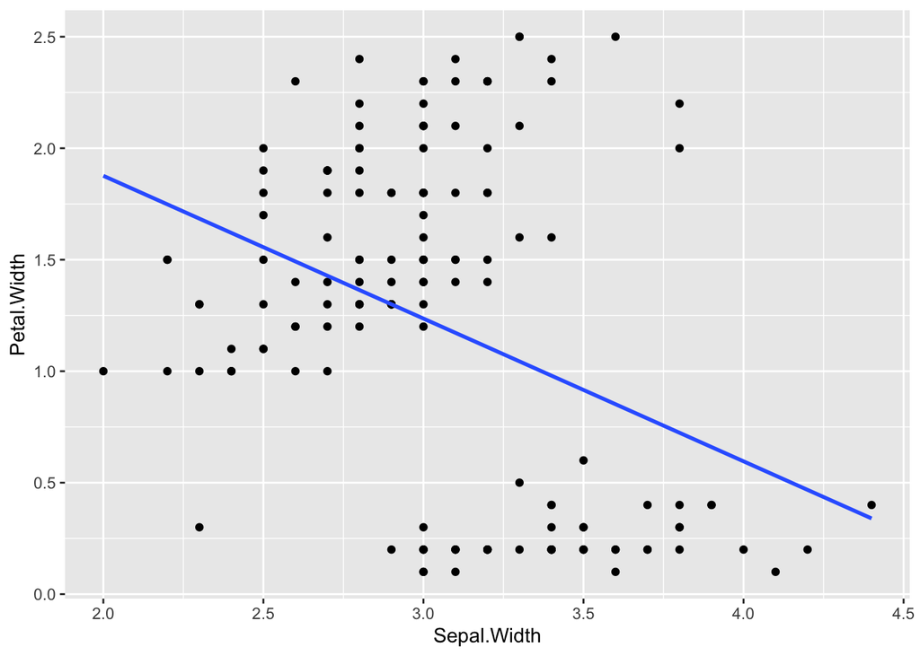

```r
ggplot(iris, aes(x = Sepal.Width,
                      y = Petal.Width)) +
  geom_point() +
  geom_smooth(method = "lm",
              se = FALSE)
```

```r
model <- lm(Petal.Width ~ Sepal.Width,
            data = iris)
summary(model)
```

```
Call:
lm(formula = Petal.Width ~ Sepal.Width, data = iris)

Residuals:
     Min       1Q   Median       3Q      Max
-1.38424 -0.60889 -0.03208  0.52691  1.64812

Coefficients:
            Estimate Std. Error t value Pr(>|t|)
(Intercept)   3.1569     0.4131   7.642 2.47e-12 ***
Sepal.Width  -0.6403     0.1338  -4.786 4.07e-06 ***
---
Signif. codes:  0 '***' 0.001 '**' 0.01 '*' 0.05 '.' 0.1 ' ' 1

Residual standard error: 0.7117 on 148 degrees of freedom
Multiple R-squared:  0.134, Adjusted R-squared:  0.1282
F-statistic: 22.91 on 1 and 148 DF,  p-value: 4.073e-06
```

The model here is $Petal.Width = 3.157 - 0.640 * Sepal.Width$. The p-value of the slope is $4.073\times 10^{-6}$, indicating strong evidence against the null. We conclude that in the larger population Petal.Width is impacted by Sepal.Width

# Problem 4

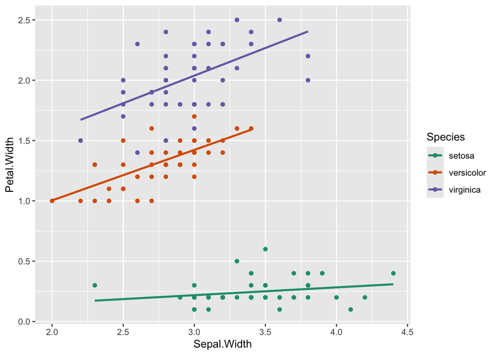

```r
ggplot(iris, aes(x = Sepal.Width,
                     y = Petal.Width,
                     color = Species)) +
  geom_point() +
  geom_smooth(method = "lm",
              se = FALSE) +
  scale_color_brewer(palette = "Dark2")
```

```r
model_par <- lm(Petal.Width ~ Sepal.Width + Species,
                data = iris)
summary(model_par)
```

```
Call:
lm(formula = Petal.Width ~ Sepal.Width + Species, data = iris)

Residuals:
     Min       1Q   Median       3Q      Max
-0.51998 -0.09476 -0.01406  0.10161  0.42333

Coefficients:
                  Estimate Std. Error t value Pr(>|t|)
(Intercept)       -0.72577    0.15298  -4.744 4.94e-06 ***
Sepal.Width        0.28348    0.04400   6.443 1.59e-09 ***
Speciesversicolor  1.26653    0.04638  27.306  < 2e-16 ***
Speciesvirginica   1.90870    0.04138  46.127  < 2e-16 ***
---
Signif. codes:  0 '***' 0.001 '**' 0.01 '*' 0.05 '.' 0.1 ' ' 1

Residual standard error: 0.1812 on 146 degrees of freedom
Multiple R-squared:  0.9446,    Adjusted R-squared:  0.9435
F-statistic: 830.2 on 3 and 146 DF,  p-value: < 2.2e-16
```

The model is $Petal.Width = -0.73 + 0.28\times Sepal.Width + 1.27 \times Speciesversicolor + 1.9 \times Speciesvirginica$ where Specieversicolor is 1 if the Specie is Versicolor and 0 otherwise. Similarly for Speciesvirginica

# Problem 5

```r
iris_aug <- augment(model_par)
glimpse(iris_aug)
```

```
Rows: 150
Columns: 9
$ Petal.Width <dbl> 0.2, 0.2, 0.2, 0.2, 0.2, 0.4, 0.3, 0.2, 0.2, 0.1, 0.2, 0.2…
$ Sepal.Width <dbl> 3.5, 3.0, 3.2, 3.1, 3.6, 3.9, 3.4, 3.4, 2.9, 3.1, 3.7, 3.4…
$ Species     <fct> setosa, setosa, setosa, setosa, setosa, setosa, setosa, se…
$ .fitted     <dbl> 0.26641061, 0.12467025, 0.18136640, 0.15301832, 0.29475868…
$ .resid      <dbl> -0.06641061, 0.07532975, 0.01863360, 0.04698168, -0.094758…
$ .hat        <dbl> 0.02030562, 0.03079967, 0.02306473, 0.02634265, 0.02174413…
$ .sigma      <dbl> 0.1817351, 0.1817094, 0.1818138, 0.1817775, 0.1816464, 0.1…
$ .cooksd     <dbl> 7.104756e-04, 1.416743e-03, 6.389248e-05, 4.670284e-04, 1.…
$ .std.resid  <dbl> -0.3702898, 0.4222885, 0.1040432, 0.2627695, -0.5287402, 0…
```

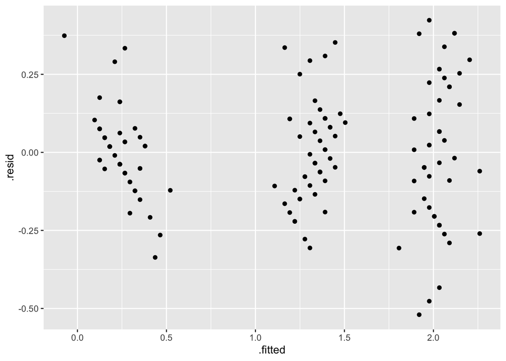

```r
ggplot(iris_aug, aes(x = .fitted,
                         y = .resid)) +
  geom_point()
```

The residual plot shows three distinct clusters corresponding to the three species, which is expected for this model. Within each cluster, the points are randomly scattered with no clear non-linear patterns, indicating that the linear assumption is valid. However, the vertical spread of residuals increases slightly from left to right, suggesting unequal variance, meaning the model’s predictions are slightly less precise for flowers with larger petal widths.